# Estadística y R - actividad 3

Equipo 2, Lote 7 (Europa)

2025-01-22

# 0.WEnv

El primer paso siempre resetear el entorno de trabajo, cargar el fichero con el que se va a trabajar (en este caso “Dataset expresión genes.csv”) y cargar todas las librerías que van a ser necesarias para el análisis.

```r
rm(list=ls()) #resetear WEnv
#thisfile_path <- file.choose() #elegir
#wd_path <- sub("/[^/]+$", "", thisfile_path) #ruta de este archivo hasta el último "/" (excluyendo nombre del archivo))
#setwd(wd_path) #setear wd_path como WD

set.seed(1999) #random seed
library(tidyverse) #ggplot2, dplyr, tidyr, ggpubr, readr...
library(stats) #ops. básicas de estadística
library(factoextra) #
library(pheatmap) #heatmaps
library(gtsummary) #tabla est.descriptiva
library(gt) #convertir dfs en tablas con estilo gtsummary
library(MASS)
library(glmnet)
library(ggplot2)
library(gridExtra)
library(jtools)
library(car)
```

# 1.Dataset

```r
df <- read.csv("1_data/Dataset expresión genes.csv") # dataframe con todas las variables
               #na.strings = este arg. dice si hay alguna cadena de texto q queramos importar como NA
df_genes <- df %>% dplyr::select(starts_with("AQ_")) # df solo de los genes
df_nogenes <- df %>% dplyr::select(-starts_with("AQ_")) # df solo de los genes
```

# 2.PCA

En este ejemplo, el objetivo era aplicar un PCA sobre las variables de expresión génica del dataset, para luego determinar el número de componentes óptimo para explicar la mayor parte de los datos (un 70% de variaza) y darle un sentido biológico a esos componentes principales.

Para aplicar el PCA en R, se puede usar la función prcomp() de la librería stats:

```r
pca.result <- prcomp(df_genes, center = TRUE, scale = TRUE )
```

```r
eigenvalues <- get_eigenvalue(pca.result) %>% round(., 2) # sacar eigenvalues y representar las cols en formato numérico estándar con 2 decimales
tabla_pca_r2 <- eigenvalues %>%
  tibble::rownames_to_column(var="Componente") %>% # guardar nombres de PCs como columna
  dplyr::select(Componente, variance.percent) %>% # generar tabla PCA componentes y R2
  dplyr::rename(R2 = variance.percent)
#guardar esta tabla
#gtsave(gt(tabla_pca_r2), filename = "4_tables/Tabla 1 - PCA Componentes R2.html") # guardar html
head(eigenvalues) # ver caract. de primeras dimensiones
```

```
##       eigenvalue variance.percent cumulative.variance.percent
## Dim.1      24.15            52.50                       52.50
## Dim.2       2.99             6.51                       59.01
## Dim.3       2.44             5.30                       64.30
## Dim.4       1.97             4.29                       68.59
## Dim.5       1.71             3.71                       72.30
## Dim.6       1.59             3.47                       75.77
```

Para obtener este 70%, debemos escoger al menos 5 PCs. Otra opción es generar un scree plot y buscar el punto de allanamiento de la gráfica (ver siguiente gráfico). Este scree plot nos muestra el porcentaje de varianza asociado a cada variable, el cual obtenemos en forma de tabla de la función anterior `get_eigenvalue` y guardamos con `gtsave()` como **Tabla 1 - PCA Componentes R2**.

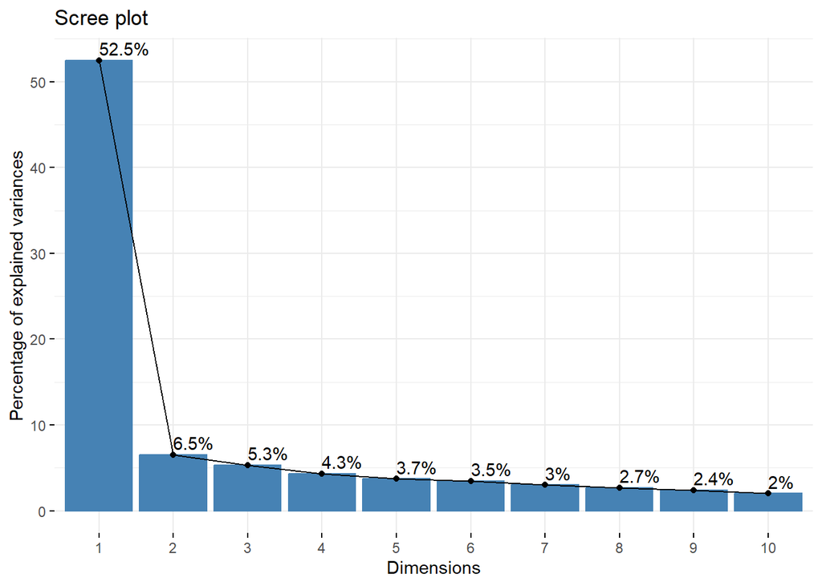

```r
fviz_eig(pca.result, addlabels = TRUE)
```

En el gráfico, se observa que el allanamiento de la gráfica ocurre en el segundo componente, ya que el componente principal explica gran parte de la varianza (52,5%) y el resto de componentes aportan mucha menos varinza. Sin embargo, como consideramos importante llegar a un 70% de varianza, decidimos trabajar con los cinco primeros componentes principales.

### B-Analizar variables y PCs

Podemos representar en dos dimensiones las variables del dataset, en forma de vectores cuya longitud indica la fuerza con la que las variables constribuyen a cada dimensión y cuya dirección indica si la asociación es positiva o negativa. Además, podemos establecer un código de colores, de modo que se represente simultáneamente el parámetro `cos2`. Este parámetro indica qué tan bien están representadas las variables por los componentes principales, en otras palabras, establece cómo de bien “caben” las variables en el espacio de menor dimensión.

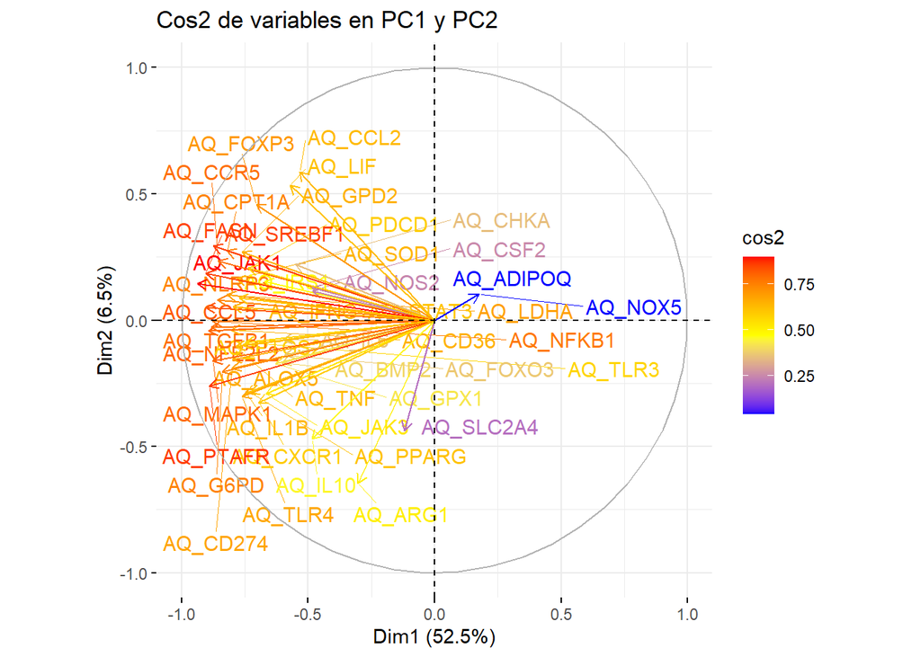

```r
fviz_pca_var(pca.result, col.var = "cos2", gradient.cols = c("blue","yellow", "red"), repel = TRUE, axes = c(1,2),
             title = "Cos2 de variables en PC1 y PC2")
```

En el gráfico, se puede apreciar cómo casi todas las variables se ajustan bien al epacio de menor dimensión, menos algunos genes como ADIPOQ o NOX5 (por sus bajos valores de ADIPO1 y NOX5). Además, en ese gráfico también se observa la tendencia que tienen muchas variables a asociarse negativamente y con bastante fuerza a la dimensión 1.

Este código de colores se puede establecer también según otros criterios. Por ejemplo, se puede aplicar un algoritmo de clusterización, para intentar agrupar las variables:

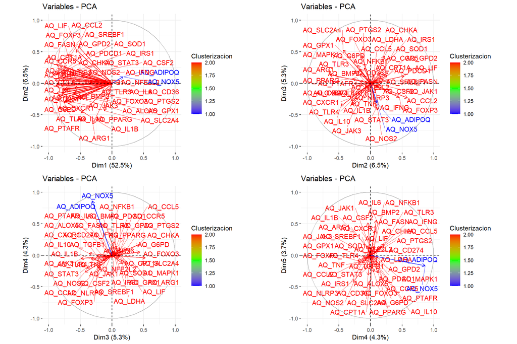

En estas gráficas, se ha representado la fuerza y la dirección de las variables con distintas combinaciones de pares de dimensiones. Para la dimensión 1 se observa la tendencia que tienen las variables de asociarse de forma negativa e intensa, tendencia que no se aprecia para el resto de dimensiones, donde hay mucha heterogeneidad. Por otro lado, la clusterización no ha sido eficiente ya que prácticamente todas las variales se agrupan en el mismo cluster, mientras que queda una pareja de variables en otro cluster que coincide con las variables con un menor cos2, es decir, este grupo consiste en las variables que peor se ajustan al modelo. Sería interesante probar otros algoritmos de clusterización (Asignatura de Algoritmos, tema 4) para analizar si alguno de ellos permite una agrupación más óptima de las variables. No lo hemos estudiado porque hemos considerado que no era el objetivo de la actividad.

Para dar un sentido y un nombre a los 5 componentes principales elegidos, hemos analizado las variables que más contribuyen a cada uno de estos componentes:

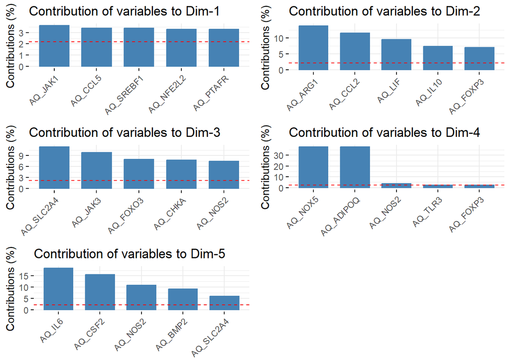

```r
graficos <- list()
for (i in 1:5) {
  grafico <- fviz_contrib(pca.result, choice ="var", axes = i, top = 5)
  graficos[[i]] <- grafico
}

graficos_varianza <- grid.arrange(grobs = graficos, nrow = 3)
```

Tras una búsqueda de estos genes en bases de datos como GenBank, se ha determinado que: 1) El componente 1 está relacionado con alteraciones en procesos inflamatorios, de respuesta inmune y estrés celular.

2. El componente 2 está relacionado con alteraciones en procesos de inmunorregulación.
3. El componente 3 está relacionado con alteraciones en el metabolismo energético y de señalización de estrés celular.
4. El componente 4 está relacionado con alteraciones en la inmunidad innata y la homeostasis.
5. El componente 5 está relacionando con alteraciones en la inflamación y la regeneración celular.

#### Loadings

La influencia de cada variable a cada componente principal se puede también analizar mediante la matriz de cargas, que se encuentra en la (**Tabla 2**) de los documentos adjuntos.

```r
pca_loadings <- as.data.frame(pca.result$rotation) #los guardamos en un df

pca_loadings <- pca_loadings %>%
  tibble::rownames_to_column(var="Gene") # gene names a columna (para no perderlos)

# los guardo en un objeto aparte para exportar con gt (ya que el formateo en scientific notation los conveirte en tipo chr.)
pca_loadings_exp <- pca_loadings %>% mutate(across(.cols = -Gene, # para toda cols excp Gene
                ~ ifelse(. < 0.1, sprintf("%.1e", .), sprintf("%.2f", .)))) # redondeamos a 1 decimal y escribimos en notación científica si son < 0.1, también con un decimal

# guardamos el df como objeto gt y exportamos para visualizar en Anexo
gtsave(gt(pca_loadings_exp), filename = "Tabla 2 - PCA Cargas.html") # guardar html
```

### C-Analizar individuos y PCs

Por un lado, puesto que para las variables aplicamos una clusterización k-means, también aplicamos esta clusterización para los pacientes:

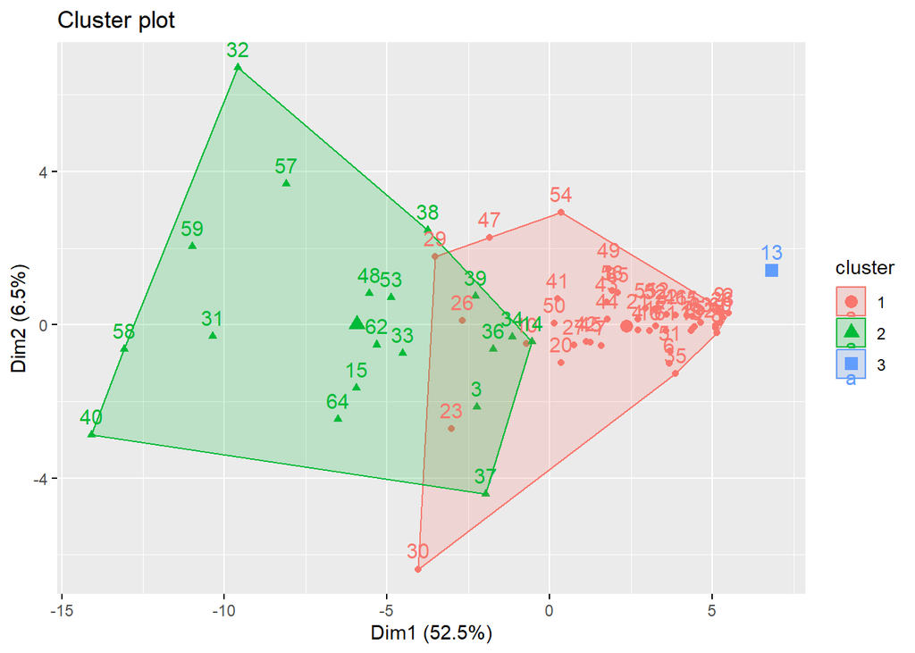

```r
kmeans2 <- kmeans(df_genes, centers = 3)
fviz_cluster(kmeans2, df_genes)
```

En el gráfico se pueden observar muchos solapamientos entre los clusters. Esto se puede deber a que, aunque los pacientes tengan fenotipos diversos, como cada gen puede estar implicado en diferentes rutas metabólicas y procesos tumorales, los pacientes pueden tener diferentes enfermedades o tipos de cáncer a la vez que un patrón génico similar o coincidente en algunos genes.

También analizamos la distribución de los pacientes en las dos primeras dimensiones, analizando el parámetro cos2:

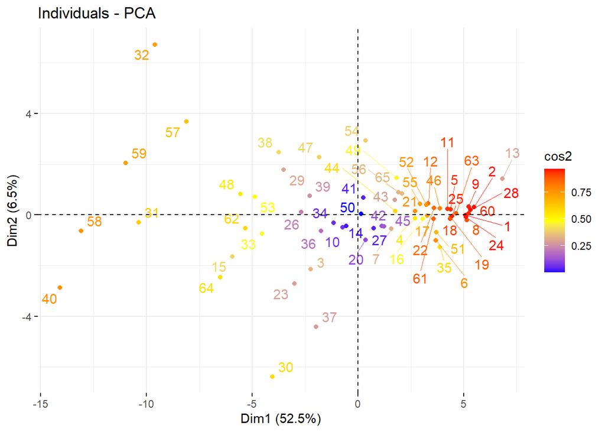

```r
fviz_pca_ind(pca.result, col.ind = "cos2", gradient.cols = c("blue","yellow", "red"), repel = TRUE)
```

En el gráfico observamos que muchos pacientes se ajustan bien al nuevo espacio reducido, con algunas excepciones, como los pacientes 10, 27, 14 ó 50 (los que vemos en azul, que tienen bajos valores de las primeras 2 PCs).

También clasificamos a los pacientes según si tenían metástasis o no, codificando para ello en el dataset una nueva variable a partir de la variable original “extension”. Una vez codificada esta variable, analizamos en un scatter plot si tomando diferentes parejas de dimensiones se podían separar estos dos grupos de pacientes:

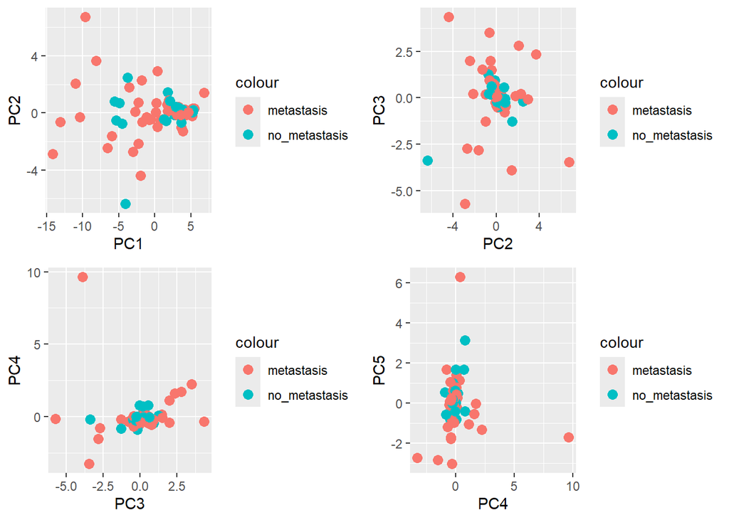

```r
df$metastasisnosi <- as.factor(ifelse( df$extension == "metastasico", "metastasis", "no_metastasis"))

df_pca_scores <- as.data.frame(pca.result$x)
df_pca_scores <- df_pca_scores[1:5]

componentes <- c("PC1", "PC2", "PC3", "PC4", "PC5")
componentes.plots <- list()

for (i in 1:(length(componentes) - 1))  {
  grafico <- ggplot(df_pca_scores, aes_string(x =componentes[i], y = componentes[i+1], color = df$metastasisnosi))+geom_point(size = 3)
  componentes.plots[[i]] <- grafico
}

grid.arrange(grobs = componentes.plots, nrow = 2)
```

No parece que ninguna gráfica, es decir, que ninguna de las parejas de dimensiones estudiadas, permitan separar a los pacientes según si tienen metástasis o no. Esto podría deberse a tres factores no necesariamente excluyentes entre sí:

- 1: PCA no es el método de reducción de dimensionalida más adecuado para analizar el papel de la expresión génica en la metástasis o no para estos individuos
- 2: el tamaño muestral no es suficientemente grande y/o el dataset de genes es insuficiente o incorrecto para explicar el fenotipo en cuestión.
- 3: necesitamos de más variables para explicar el fenotipo de interés.

## Tabla descriptiva de las PCs

*Objetivo*: hacer una tabla donde se recojan medidas descriptivas de cada tercil de las 5 primeras PCs. Para ello, antes se ha chequeado la normalidad para ver qué test aplicar entre las medias/medianas de los 3-iles.

### Chequear normalidad

En la tabla se han incluido los test de contrastes de hipótesis para comparar los 3-iles, de modo que hay que elegir el test apropiado antes de construirla. Para ello se ha analizado la uniformidad de expresión para cada gen a lo largo de los terciles de cada componente del PCA, es decir,la igualidad de medias(e.paramétrica) o medianas (e. no paramétrica) de 3 grupos (los terciles del PC en cuestión). Se ha calculado entonces la normalidad para las variables de expresión génica, usando:

- 22. con d. normal: one way ANOVA
- 22. con d. no normal: test de Kruskal-Wallis

Se han elegido estos test porque las muestras no son emparejadas.Por tanto, se ha calculado normalidad en df_genes y se han almacenado las vars. con d. normal en un vector y aquellas con d. no normal en otro:

```r
# creo un tibble para guardar datos del test de normalidad y lo convierto a data frame
norm_test_1 <- tibble(`Variable` = rep(NA, 46),
                      `Test utilizado` = rep("Test de Shapiro-Wilk", 46),
                      `Valor p` = rep(NA, 46),
                      `Interp` = rep(NA, 46)) %>% as.data.frame()
# bucle para rellenar tabla de resultado
for (i in 1:length(df_genes)) {
  norm_test_1[i,1] <- colnames(df_genes)[[i]] # rellenar col 1 de tabla 1
  norm_test_1[i,2] <- "Shapiro-Wilk" # rellenar col 2 de tabla 1
  shapiro_result <- shapiro.test(df_genes[[i]]) # calculo el test y lo guardo en shapiro_result
  pvalue = shapiro_result$p.value # guardo el pvalue en otra variable
  # if-else para rellenar col 3
  if (pvalue < 0.001) {pvalue_f <- signif(pvalue, digits = 3)} # redondear pvalue a 3 decimales en SNotation
  else  {pvalue_f <- round(pvalue, 3)} # expresar pvalue redondeado a 3 caracteres
  norm_test_1[i, 3] <- as.numeric(pvalue_f)
  # rellenar col 4 en función de pvalor
  if (pvalue < 0.05) {norm_test_1[i, 4] <- "D. NO normal"}
  else {norm_test_1[i, 4] <- "D. NORMAL"}
}
# castear norm_test_1$Interpretacion como tipo factor para ver summary()
summary(as.factor(norm_test_1$Interp))
```

```
## D. NO normal
##           46
```

Todos los genes tienen una distribución no normal, por lo que se han testeado las diferencias entre sus terciles con el *test de Kruskal-Wallis*.

### Calcular 3-iles

```r
# Con un bucle for
for (i in 1:length(df_pca_scores)) {
  # guardo terciles 1 y 2 en variables
  t1 = quantile(df_pca_scores[[i]], probs=c(1/3))
  t2 = quantile(df_pca_scores[[i]], probs=c(2/3))
  # defino nombre de nueva columna
  column_name = paste0("T", colnames(df_pca_scores)[[i]])
  # genero
  df_pca_scores[[column_name]] = as.factor(cut(df_pca_scores[[i]], c(-Inf, t1, t2, Inf), labels = c("t1", "t2", "t3")))
}
summary(df_pca_scores)# check result
```

```
##       PC1               PC2                PC3                PC4
##  Min.   :-14.100   Min.   :-6.37460   Min.   :-5.71360   Min.   :-3.27180
##  1st Qu.: -2.690   1st Qu.:-0.51948   1st Qu.:-0.29424   1st Qu.:-0.36690
##  Median :  1.579   Median :-0.01809   Median : 0.06317   Median :-0.22442
##  Mean   :  0.000   Mean   : 0.00000   Mean   : 0.00000   Mean   : 0.00000
##  3rd Qu.:  3.697   3rd Qu.: 0.43998   3rd Qu.: 0.54559   3rd Qu.: 0.02959
##  Max.   :  6.823   Max.   : 6.71901   Max.   : 4.34886   Max.   : 9.63283
##       PC5           TPC1    TPC2    TPC3    TPC4    TPC5
##  Min.   :-3.04431   t1:22   t1:22   t1:22   t1:22   t1:22
##  1st Qu.:-0.47613   t2:21   t2:21   t2:21   t2:21   t2:21
##  Median : 0.03238   t3:22   t3:22   t3:22   t3:22   t3:22
##  Mean   : 0.00000
##  3rd Qu.: 0.38271
##  Max.   : 6.28638
```

### Tabla descriptiva PCA

Para la correcta visualización de la tabla, se ha adjuntado como un archivo a parte, llamado *Tabla 3*

```r
# Construir tabla descriptiva
#############################
df_d_pca <- cbind(df_genes, df_pca_scores) # concatenamos df de expresión génica y df con las pcs

reset_gtsummary_theme() # resetear opciones de tema para gtsummary
theme_gtsummary_compact() # usar tema `Compact` en gtsummary
```

```
## Setting theme "Compact"
```

```r
# Defino vectors con nombres de vars
gene_varnames <- c(names(df_genes))
pca_varnames <- names(df_pca_scores)
d_pca_varnames <- names(df_d_pca)
strata_vars <- c("PC1", "PC2", "PC3", "PC4", "PC5")
by_vars <- c("TPC1", "TPC2", "TPC3", "TPC4", "TPC5")

result_list <- map2(strata_vars, by_vars, ~ {
  df_d_pca %>%
    # Seleccionar solo las columnas relevantes: x es la PC, y es su col de terciles
    dplyr::select(all_of(gene_varnames), .y) %>%
    # Construimos tabla con tbl_summary
    tbl_summary(by = .y, # estratificar en función de 3-iles
                statistic = all_continuous() ~ "{median} ({p25}, {p75})", #mediana + IQR
                # digitos en scientific notation
                digits = all_continuous() ~ function(x) format(x, digits = 2, scientific = TRUE),
                missing = "no") %>%  # excluir NAs
    # Prueba de Kruskal-Wallis solo a vars de expresión génica
    add_p(test = all_continuous() ~ "kruskal.test", include = all_of(gene_varnames)) %>%
    # añadir corrección de pvalue para disminuir falsos positivos
    add_q(method = "bonferroni", pvalue_fun = NULL, quiet = NULL) %>%
    bold_p(t = 0.05, q = TRUE) #destacar pvalues significativos en negrita
})
# Convertir cada tabla en result_list a gt
gt_tables <- map(result_list, as_gt)
# Imprimir cada tabla individualmente (guardadas en documento adjunto)
#walk(gt_tables, print) #No ejecutar en el html
# Guardar cada tabla individualmente como .html
#walk2(gt_tables, seq_along(gt_tables), ~ gtsave(.x, filename = paste0("Tabla 3 - Descriptiva PC", .y, ".html"))) #No ejecutar en el html
```

Aquí tenemos comparativas en los valores de expresión génica por cada tercil de cada PC. Las hemos sacado en tablas diferentes (`Tabla 3`) y, de acuerdo a los resultados del scree plot, en cada componente vemos que se reduce la variabilidad explicada de manera progresiva a partir de la 2ª y con una drástica diferencia entre la primera y el resto.

# 3.Modelo predictivo Reg.Logística*

## Introducción

El objetivo de este análisis es evaluar cómo influyen una serie de variables independientes sobre una variable dependiente. En este caso la variable dependiente es “metástasis”, una variable categórica con dos niveles, que determina si los pacientes tienen metástasis o no. Por otro lado, las variables independientes son los cinco componentes principales analizados en el PCA, junto con el resto de variables del dataset original (sin contar con los datos de expresión génica, puesto que ya hemos reducido la dimensionalidad y los tenemos representados con los componentes principales).

Tenemos demasiadas variables independientes por lo que, antes de aplicar la regresión logística, decidimos usar un modelo de regularización, para reducir el número de variables. Al principio, intentamos usar LASSO, un modelo de regularización que aplica una penalización sobre las variables y permite seleccionar solo aquellas variables con un coeficiente que tras la penalización tengan un valor mayor a 0, que son las variables más importantes a la hora de hacer el análisis. Sin embargo, este método no era apropiado para este conjunto de datos, ya que este tipo de regularización eliminaba todas las variables del dataset.

La regularización tipo Ridge también fue considerada, ya que no elimina variables pero sí reduce sus coeficientes a valores cercanos a 0, teniendo en cuenta sus efectos pero dándoles poco peso. Este método dejaba nuestro dataset con coeficientes entre órdenes de $10^{-3}$ y $10^{-5}$, pero teníamos tantas variables que preferimos usar ElasticNet (una solución intermedia entre Lasso y Ridge) para evitar sobreajuste o multicolinealidad derivada de variables altamente correlacionadas.

A continuación se muestra el código aplicado para cada uno de los modelos de regularización que probamos:

## Preprocesado previo a regularización

Antes de poder aplicar la regularización, generamos un dataframe con todas las variables (salvo las de expresión génica, que hemos proyectado en un espacio de menor dimensión en forma de componentes) y las convertimos a valores numéricos, ya que es el tipo de dato que necesita las funciones glmnet() y cv.glmnet()

```r
# las variables factor están en tipo character, tengo que convertirlas a numérico pq glmnet no admite tipo factor
# casteo a numérico variables char
df_nogenes <- df %>% dplyr::select(-starts_with("AQ_"), -X, -id, -extension) # df de vars q no son genes

df_char <- df_nogenes[ ,sapply(df_nogenes, is.character)]# guardamos las vars factor en un vector lógico
df_char$antiemesis <- as.character(ifelse(df$corticoides=="antiemesis", "1", "0"))
df_char$corticoides <- as.character(ifelse(df$corticoides=="si", "1", "0"))

df_nochar <- df_nogenes[, sapply(df_nogenes, is.numeric)]
df_nochar <- as.data.frame(scale(df_nochar, center=TRUE, scale=TRUE))
# convierto variables tipo char a factor y luego a numeros para codificarlas de manera que glmnet las entienda
for (i in colnames(df_char)) {
  df_char[[i]] <-as.numeric(as.factor(df_char[[i]]))
}
# y concateno df_char, df_nochar y df5 pcs en df_lasso
df_regularizacion <- cbind(df_char, df_nochar)

# ahora tb dejo bien formateada la variable respuesta
df$metastasis = as.factor(as.numeric(ifelse(df$extension == "metastasico", 1, 0)))

# defino variables para df_lasso
cols = c(colnames(df_regularizacion))
x <- df_regularizacion[, cols]
y <- df$metastasis

# convertir a matriz para incluir interacciones entre todas las variables
formula <- as.formula(paste("y ~", paste(names(x), collapse = " * "))) # Crear una matriz de diseño con interacciones entre todas las variables
```

## Regularización

### Ridge

Primeramente, se testearon con la función glmnet() diferentes valores de lambda establecidos previamente en la variable grid. Al graficar estos valores de lambda, pudimos orientar entorno a qué rango de valores se encontraba el lambda óptimo. Con esta información, ajustamos el rango del grid y usamos cv.glmnet() para calcular el lambda óptimo y con ello, usar la función glmnet() y calcular los coeficientes de las variables con el modelo de Ridge.

```r
set.seed(1456)
# construimos un grid para encontrar lambda óptimo (el que minimice el error predicho por el modelo vs el dato real)
grid <- 10^seq(1.5, -1.5, length=100)

# y aplicamos ridge (alpha=0)
ridge <- glmnet(x, y, alpha=0, lambda=grid, family="binomial")
dim(coef(ridge))
```

```
## [1]  57 100
```

```r
head(coef(ridge))
```

```
## 6 x 100 sparse Matrix of class "dgCMatrix"
```

```
##   [[ suppressing 100 column names 's0', 's1', 's2' ... ]]
```

[output not shown]

[output cut: 92 more lines]

[output not shown]

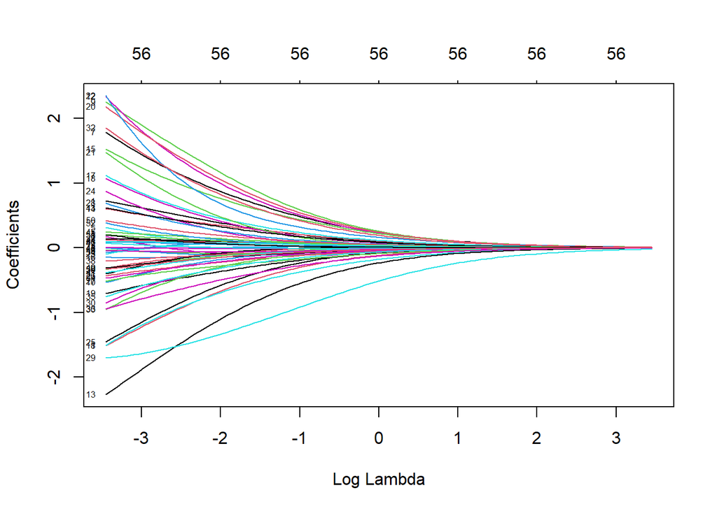

```r
plot(ridge, xvar="lambda", label=TRUE) #log lambda plot > nos permite hacernos una idea de por dónde estará el lambda óptimo
```

Estos plots nos dan una idea gráfica del valor óptimo de lambda para ridge. Probablemente sea un valor entre $0$ y $10^{2}$.

```r
x_matrix <- as.matrix(x)
y_matrix <- as.matrix(y)
# hago un m
#modelo de cross validation
ridge_cv <- cv.glmnet(x_matrix, y_matrix, alpha=0, lambda=grid, family="binomial")
lambda_min <- ridge_cv$lambda.min # este es el lambda que menor error nos da para el modelo, me lo guardo en un objeto
# y lo uso para generar modelo de ridge
ridge_cv <- glmnet(x_matrix, y_matrix, alpha=0, lambda = lambda_min, family="binomial")
coefs <- as.data.frame(as.matrix(coef(ridge_cv))) %>% tibble::rownames_to_column(var="Var")#guardar coefs en df
coefs <- coefs[order(-coefs$s0), ] # Ordenar los coeficientes de mayor a menor
head(coefs, 10) # ver los 10 primeros más significativos
```

```
##            Var          s0
## 1  (Intercept) 0.932015347
## 16 corticoides 0.009817126
## 8          ETE 0.009701666
## 10 hepatopatia 0.009121918
## 21  dolor_garg 0.009115716
## 13         ITU 0.008951148
## 23      fiebre 0.008633749
## 33  dolor_abdo 0.007807564
## 18      disnea 0.005356453
## 15  neuropatia 0.004241901
```

Todas las variables tienen $\beta$s muy bajos y son demasiadas. Aplicamos Lasso para ver si podemos eliminar algunas.

### Lasso

El flujo de trabajo con Lasso es igual que el usado el Ridge, solo que ahora alpha tiene un valor 1 y la finalidad es reduir el número de variables para aplicar posteriormente al modelo de regresión.

```r
set.seed(1456)
grid <- 10^seq(-4,1, lenght=100)
lasso <- glmnet(x, y, alpha=1, lambda=grid, family="binomial")
dim(coef(lasso))
```

```
## [1] 57  6
```

```r
print(coef(lasso))
```

```
## 57 x 6 sparse Matrix of class "dgCMatrix"
##                       s0        s1         s2          s3          s4
## (Intercept)    0.9597758 0.9597758 0.89529256 -9.68058986 -39.5736810
## sexo           .         .         .           1.09977660   0.5530948
## exfumador      .         .         .           .            .
## hta            .         .         .           .            .
## dm             .         .         .           .            0.1498231
## alergia        .         .         .           .            .
## cardiopatia    .         .         .           .            .
## ETE            .         .         .           3.13285482  11.8793043
## neumopatia     .         .         .          -1.97663596  -5.4475921
## hepatopatia    .         .         .           3.53139844  10.8777620
## colelitiasis   .         .         .           .            .
## utolitiasis    .         .         .          -1.74412111  -8.0355476
## ITU            .         .         .           4.49379111  14.5609740
## renal          .         .         .          -3.27072104  -6.6683014
## neuropatia     .         .         .           0.10978122   2.4753974
## corticoides    .         .         0.05748791  2.01863445   8.6043833
## tos            .         .         .           .            .
## disnea         .         .         .           1.70185406   6.8895788
## expect         .         .         .           1.62794268   6.1827838
## secrecion      .         .         .          -0.59499928  -2.4402565
## dolor_garg     .         .         .           1.99397268   3.1150455
## escalofrios    .         .         .           1.79430276   8.0980406
## fiebre         .         .         .           1.07524169   1.3507998
## diarrea        .         .         .           .           -1.1384645
## nauseas        .         .         .           .            .
## vomitos        .         .         .          -1.48177981  -2.2631837
## cefalea        .         .         .          -1.11830909  -5.1290238
## mareo          .         .         .          -0.23558694  -2.0190119
## cansancio      .         .         .           0.92834925   5.8417491
## anosmia        .         .         .          -0.35082824   .
## disgueusia     .         .         .          -0.91258847  -0.5503213
## dolor_hueso    .         .         .          -0.49420865  -2.6341972
## dolor_abdo     .         .         .           3.09649752  10.8366436
## perd_ape       .         .         .          -1.03785173  -2.9448838
## tumor          .         .         .           .           -1.4237294
## trat           .         .         .          -1.43343916  -5.0996294
## antiemesis     .         .         .          -0.81955421  -1.9628914
## edad           .         .         .           .            .
```

[output cut: 62 more lines]

```
## score_dieta      .
## chol             4.08879029
## hdl              0.05028042
## hierro           0.61778893
## igA              .
## igE              0.44437510
## igG              .
## igN             -3.08034726
## ldl              1.80040049
## pcr              .
## transferrina     4.14933424
## trigliceridos    0.14828117
## cpk             -0.81425241
## calidad_fisica   1.92111710
## calidad_mental  -0.48507513
```

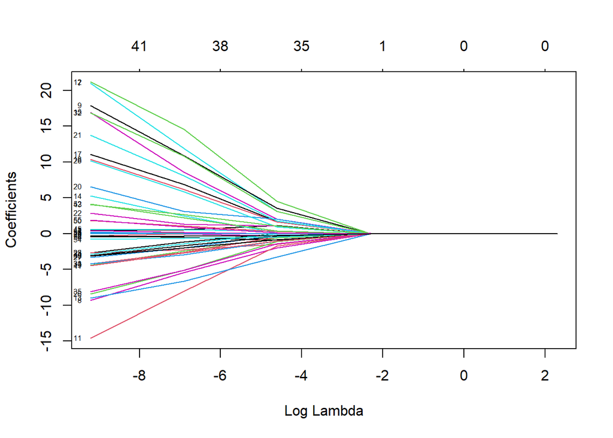

```r
plot(lasso, xvar="lambda", label=TRUE) #log lambda plot
```

Estos plots nos dan una idea gráfica del valor óptimo de lambda para Lasso. Ahora vemos que el valor óptimo estará entre $10^{-4}$ y $10^{-2}$.

```r
# hago un modelo de cross validation
grid <- 10^seq(-3,0, lenght=100)
lasso <- cv.glmnet(x_matrix, y_matrix, alpha=1, lambda=grid, family="binomial")
lasso_cv <- glmnet(x_matrix, y_matrix, alpha=1, lambda = lambda_min, family="binomial")
coefs <- as.data.frame(as.matrix(coef(lasso_cv))) %>% tibble::rownames_to_column(var="Var")#guardar coefs en df
# Ordenar los coeficientes de mayor a menor y filtrar los que sean 0
coefs <- coefs[order(-coefs$s0), ] %>% filter(`s0`!=0.000000000000)
coefs # filtrar los que sean
```

```
##           Var        s0
## 1 (Intercept) 0.9597758
```

```r
head(coefs, 10) # ver los 10 primeros más significativos
```

```
##           Var        s0
## 1 (Intercept) 0.9597758
```

Lo que vemos es que el lambda.min (el que minimiza la diferencia $V_{real}-V_{predicha}$) elimina todas las variables (hace sus coeficientes 0) menos el intercept, por lo que esto no resulta útil. Otra opción que probamos fue,en vez de el lambda mínimo, usar el lambda “within one standard error from the minimum”. Este es el lambda que minimiza el CV error + 1 SE (si no, el valor de lambda mínimo hace se eliminen todas las variables). Aplicamos ese lambda (lambda.1se) en el modelo de Lasso:

```r
lambda_min <- lasso$lambda.min
lambda_1se <- lasso$lambda.1se
lasso_cv <- glmnet(x_matrix, y_matrix, alpha=1, lambda = lambda_1se, family="binomial")
coefs <- as.data.frame(as.matrix(coef(lasso_cv))) %>% tibble::rownames_to_column(var="Var")#guardar coefs en df
# Ordenar los coeficientes de mayor a menor y filtrar los que sean 0
coefs <- coefs[order(-coefs$s0), ] %>% filter(`s0`!=0.000000000000)
head(coefs, 10) # ver los 10 primeros más significativos
```

```
##           Var        s0
## 1 (Intercept) 0.9597758
```

Este lambda también elimina todas las variables, ya que en realidad es muy cercano al `lambda_min`, como podemos ver a continuación:

```r
cat("Lambda min:", lambda_min, "\nLambda + 1SE:", lambda_1se)
```

```
## Lambda min: 1
## Lambda + 1SE: 1
```

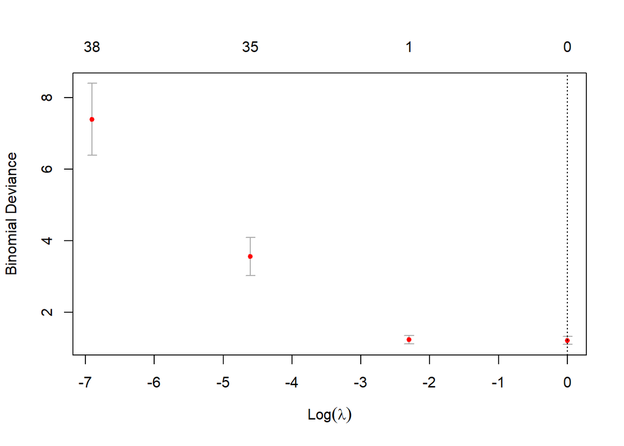

```r
plot(lasso)# este gráfico nos enseña las variables retenidas para los distintos labmda
```

Los cálculos muestran que $\lambda_{min} = \lambda_{mín+1 S.E.} = 1$. En este gráfico donde vemos los resultados de las distintas CVs y las variables retenidas arriba, un lambda de 1 ($log_{\lambda} = 0$) nos deja un modelo de 0 variables. Además, el lambda mínimo tiene un s.e. muy pequeño que nos dejará otra vez con un modelo con 0 variables a pesar de usar el $\lambda_{mín+1 S.E.}$ y reducir más el lambda nos llevaría a una desviación (error) muy alta, por lo que probaremos con ElasticNet.

### ElasticNet

En este caso, a parte de calcular el lambda óptimo, también hay que calcular el alpha óptimo:

```r
set.seed(1456)
seq_alpha <- seq(0.01,0.99,by=0.01) # limitamos el rango para no hacer ni ridge ni lasso
grid <- 10^seq(-3, 3, length=100)

best_alpha <- NULL
best_lambda <- NULL
min_error <- Inf

# encontrar el mejor alpha
for (alpha in seq_alpha) {
  enet_cv <- cv.glmnet(x_matrix, y_matrix, alpha=alpha, lambda=grid, family="binomial")
  # Obtener valor de lambda óptimo elegido automáticamente
  lambda_min<-enet_cv$lambda.min
  #Obtener el error de validación cruzada mínimo
  cv_error <- min(enet_cv$cvm)
  #Actualizar el mejor alpha y lambda si se encuentra un error de cv menor
  if (cv_error < min_error) {
    min_error <- cv_error
    best_alpha <- alpha
    best_lambda <- lambda_min
  }}

# Imprimir el mejor alpha y lambda encontrados tras el bucle
cat("Mejor alpha:", best_alpha, "\n")
```

```
## Mejor alpha: 0.65
```

```r
cat("Mejor lambda:", best_lambda, "\n")
```

```
## Mejor lambda: 1000
```

Ahora que hemos encontrado un alpha intermedio entre Lasso y Ridge, vamos a probar a utilizarlo con `cv.glmnet()` para encontrar el lambda óptimo.

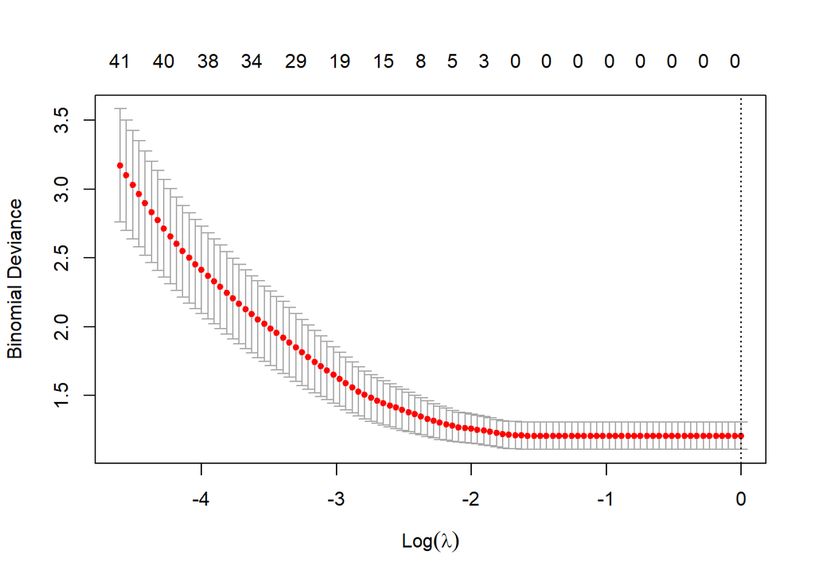

```r
grid <- 10^seq(0, -2, length=100)
# hago un modelo de cross validation
enet_cv <- cv.glmnet(x_matrix, y_matrix, alpha=best_alpha, lambda=grid, family="binomial")
plot(enet_cv)
```

```r
lambda_1se <- enet_cv$lambda.1se
lambda_1se
```

```
## [1] 1
```

```r
enet_cv <- glmnet(x_matrix, y_matrix, alpha=best_alpha, lambda=10^-1.3, family="binomial")
coefs_enet <- as.data.frame(as.matrix(coef(enet_cv))) %>% tibble::rownames_to_column(var="Var")#guardar coefs en df
# ordenamos de manera descendente y filtramos los == 0
coefs_enet <- coefs_enet[order(-coefs_enet$s0), ] %>% filter(`s0`!=0.000000000000) %>% # quitamos las == 0
  filter(Var != "(Intercept)") # quitamos el intercept
coefs_enet
```

```
##            Var          s0
## 1          ETE  1.06996571
## 2  hepatopatia  0.92234940
## 3   dolor_garg  0.83403737
## 4  corticoides  0.76108004
## 5   dolor_abdo  0.69599038
## 6         chol  0.45606000
## 7         sexo  0.33759453
## 8          ITU  0.31138643
## 9   neuropatia  0.11303958
## 10         ldl  0.07852175
## 11      expect  0.03663046
## 12      hierro  0.01796758
## 13         igN -0.06608286
## 14         cpk -0.09129705
## 15   secrecion -0.19805606
## 16  neumopatia -0.40731570
## 17  antiemesis -0.52420360
## 18       renal -1.04784008
## 19     anosmia -1.43284708
```

Aquí obtenemos 19 coeficientes (más que en Lasso) y con valores más elevados que en Ridge(órdenes de magnitud cercanos a 1), por lo que nos ha parecido un buen resultado para regularizar nuestro dataset.

# 4.Modelo RL

### Preprocesado previo a modelo

Una vez seleccionadas las variables del dataset original para el modelo de regresión logística (vector `reg_vars`), añadimos también los terciles de los cinco primeros componentes principales, en forma de variables dummy que indican a qué tercil de cada componente pertenece la expresión de cada gen para un paciente (calculados en el punto 2).

```r
reg_vars <- c(coefs_enet$Var) # Guardamos variables de elasticnet en vectror
df_regresion <- df_regularizacion %>% dplyr::select(all_of(reg_vars <- c(coefs_enet$Var))) # creamos df_regresion (vacío)
#Tambien hay que añadir la variable categorica
df_regresion$metastasis <- as.factor(df$metastasis)

# Convertimos las variables en tipo factor
for (var in reg_vars) {
  if (var %in% colnames(df_char)) { # castear solo las que esten en df_char, que son las tipo factor
    df_regresion[[var]] <- as.factor(df_regresion[[var]])
  }}
```

Una vez tuvimos en un dataframe todas las variables del dataset original que hemos seleccionado para la regresion logística, junto con los terciles de los cinco primeros componentes codificados en forma de factor, hicimos la regresión logística:

### modelo RL 1

```r
df_regresion <- cbind(df_regresion, df_pca_scores[6:10]) #añadimos al dataframe de regresion los terciles de las PCs
reg_vars <- colnames(df_regresion) #guardo colnames en un vector
reg_vars_x <- setdiff(reg_vars, "metastasis")
formula <- as.formula(paste("metastasis ~", paste(reg_vars_x, collapse = "+")))

modelo_regresion <- glm(formula, data = df_regresion, family = "binomial")

cat("ODDS RATIOS\n")
```

```
## ODDS RATIOS
```

```r
exp(coef(modelo_regresion)) #OR
```

```
##   (Intercept)          ETE2  hepatopatia2   dolor_garg2  corticoides2
##  6.719836e+53  3.971753e+52  1.472489e-25  1.073539e+29  1.614298e+97
##   dolor_abdo2          chol         sexo2          ITU2   neuropatia2
##  2.235073e+90  1.245236e+31  1.232327e+47 5.021260e-129  3.131873e-08
##           ldl       expect2        hierro           igN           cpk
##  1.035062e+17  9.558040e-10  3.514682e+24  2.694250e-10  3.156164e-15
##    secrecion2   neumopatia2   antiemesis2        renal2      anosmia2
##  4.283154e-12  8.686263e-79  2.807491e-63  1.776208e-07  1.274893e-01
##        TPC1t2        TPC1t3        TPC2t2        TPC2t3        TPC3t2
##  1.929927e-35  1.489971e+01  1.704958e-67  4.255805e-48  2.736559e+78
##        TPC3t3        TPC4t2        TPC4t3        TPC5t2        TPC5t3
##  6.476967e+89  1.860618e+89  1.408899e-77  1.715128e-17  1.322220e+09
```

```r
cat("\nICs\n")
```

```
##
## ICs
```

```r
head(exp(confint(modelo_regresion)), 10) # ver primeros 10 ICs
```

```
##              2.5 % 97.5 %
## (Intercept)      0    Inf
## ETE2             0    Inf
## hepatopatia2     0    Inf
## dolor_garg2      0    Inf
## corticoides2     0    Inf
## dolor_abdo2      0    Inf
## chol             0    Inf
## sexo2            0    Inf
## ITU2             0    Inf
## neuropatia2      0    Inf
```

```r
cat("\nMODEL SUMMARY\n")
```

```
##
## MODEL SUMMARY
```

```r
rl_summary <- summ(modelo_regresion) #pvalores
rl_summary$coeftable
```

```
##                     Est.       S.E.        z val.         p
## (Intercept)   123.942074  3370403.1  3.677366e-05 0.9999707
## ETE2          121.113632  7766018.4  1.559533e-05 0.9999876
## hepatopatia2  -57.177673  1316523.0 -4.343082e-05 0.9999653
## dolor_garg2    66.845929  3268150.9  2.045375e-05 0.9999837
## corticoides2  223.829654  3682940.4  6.077472e-05 0.9999515
## dolor_abdo2   208.036932   426593.9  4.876697e-04 0.9996109
## chol           71.599463  3896565.7  1.837502e-05 0.9999853
## sexo2         108.430404  9867302.9  1.098886e-05 0.9999912
## ITU2         -295.419796 22302518.8 -1.324603e-05 0.9999894
## neuropatia2   -17.279050 14402750.8 -1.199705e-06 0.9999990
## ldl            39.178408   371199.8  1.055453e-04 0.9999158
## expect2       -20.768468  8044621.8 -2.581659e-06 0.9999979
## hierro         56.518991   228574.3  2.472675e-04 0.9998027
## igN           -22.034731   309951.9 -7.109080e-05 0.9999433
## cpk           -33.389419  1560448.3 -2.139733e-05 0.9999829
## secrecion2    -26.176331  5035816.7 -5.198031e-06 0.9999959
## neumopatia2  -179.742479 11593494.7 -1.550374e-05 0.9999876
## antiemesis2  -144.030570  6283296.6 -2.292277e-05 0.9999817
## renal2        -15.543615 47734806.7 -3.256243e-07 0.9999997
## anosmia2       -2.059723 12702824.2 -1.621468e-07 0.9999999
## TPC1t2        -79.932996   679321.0 -1.176660e-04 0.9999061
## TPC1t3          2.701342  2769148.7  9.755135e-07 0.9999992
## TPC2t2       -153.739661  4186820.0 -3.671991e-05 0.9999707
## TPC2t3       -109.075801  7243475.9 -1.505849e-05 0.9999880
## TPC3t2        180.608339  5883307.7  3.069844e-05 0.9999755
## TPC3t3        206.798326  7037067.3  2.938700e-05 0.9999766
## TPC4t2        205.550982  9989385.7  2.057694e-05 0.9999836
## TPC4t3       -176.956243   677920.6 -2.610280e-04 0.9997917
## TPC5t2        -38.604459  6762495.5 -5.708611e-06 0.9999954
## TPC5t3         21.002578  6282993.1  3.342766e-06 0.9999973
```

Para poder interpretar los resultados del modelo de regresión logística, necesitamos sacar los Odds-Ratios (OR), ya que los coeficientes no son directamente interpretables. Para ello, hay que obtener la forma exponencial de dichos coeficientes. En estos OR, lo que se obtiene es el efecto, positivo o negativo, que las variables independientes tienen sobre la clase de interés de la variable dependiente (en este caso, 1, es decir, tener metástasis) con respecto a la clase de referencia (en este caso 0, es decir, no tener metástasis). También hay que tener en cuenta si este efecto es significativo o no, lo cual se puede saber a través del pvalor o analizando los intervalos de confianza. Lo que se observa, tanto en el pvalor como con los intervalos de confianza, es que el modelo de regresión logística no ha sido óptimo, puesto que los IC van de 0 a infinito y los pvalores salen cercanos a 1. Esto podría deberse a una colinealidad elevada entre las variables, lo cual se puede confirmar con la función vif(). Si el parámetro vif() es mayor de 5, esto es indicativo de una alta colinealidad:

```r
#Comprobamos colinealidad
vif <- as.data.frame(vif(modelo_regresion))
vif <- vif[order(-vif$`GVIF^(1/(2*Df))`), ]
cat("MODELO 1")
```

```
## MODELO 1
```

```r
head(vif, 10)
```

```
##                 GVIF Df GVIF^(1/(2*Df))
## neuropatia 340015.37  1        583.1084
## sexo       272603.43  1        522.1144
## antiemesis 200558.73  1        447.8378
## neumopatia 192185.02  1        438.3891
## chol       175603.76  1        419.0510
## secrecion  100835.68  1        317.5463
## cpk        100192.64  1        316.5322
## expect      97614.54  1        312.4333
## ITU         25428.46  1        159.4630
## ETE         10149.21  1        100.7433
```

En la tabla se observan variables con un vif muy alto,es decir, hay una alta colinealidad.

### modelo RL 2

```r
#habria que quitar aquellas variables con un VIF mayor de 5:
variables_a_eliminar <- c("TPC1", "neumopatia", "neuropatia", "corticoides", "secrecion", "dolor_abdo", "chol", "hierro", "igN", "cpk")

# Eliminar las variables específicas de la fórmula
reg_vars_modificadas <- setdiff(reg_vars_x, variables_a_eliminar)
# Deseleccionar del df
df_regresion_2 <- df_regresion[, reg_vars_modificadas]

# Crear la nueva fórmula con las variables modificadas
formula_modificada <- as.formula(paste("metastasis ~", paste(reg_vars_modificadas, collapse = "+")))

modelo_regresion2 <- glm(formula_modificada, data = df_regresion, family = "binomial")

# Ver resultados
cat("ODDS RATIOS\n")
```

```
## ODDS RATIOS
```

```r
exp(coef(modelo_regresion2)) #OR
```

```
##  (Intercept)         ETE2 hepatopatia2  dolor_garg2        sexo2         ITU2
## 3.223588e+00 3.152157e+08 1.164566e+08 1.941775e+08 6.921944e-01 1.247552e+08
##          ldl      expect2  antiemesis2       renal2     anosmia2       TPC2t2
## 1.779774e+00 9.682231e-01 2.757964e-01 4.775246e-10 1.284380e-08 1.612312e+00
##       TPC2t3       TPC3t2       TPC3t3       TPC4t2       TPC4t3       TPC5t2
## 1.589773e+00 1.426244e+00 8.610330e+00 4.834456e-01 8.749140e-02 1.258276e+00
##       TPC5t3
## 2.538613e+00
```

```r
cat("\nICs\n")
```

```
##
## ICs
```

```r
round(exp(confint(modelo_regresion2)), 2) # ver primeros 10 ICs
```

```
##              2.5 % 97.5 %
## (Intercept)   0.34  42.26
## ETE2          0.00     NA
## hepatopatia2  0.00     NA
## dolor_garg2   0.00     NA
## sexo2         0.11   4.26
## ITU2          0.00     NA
## ldl           0.83   5.02
## expect2       0.11  10.53
## antiemesis2   0.05   1.22
## renal2          NA    Inf
## anosmia2        NA    Inf
## TPC2t2        0.17  16.72
## TPC2t3        0.26  10.33
## TPC3t2        0.26   8.31
## TPC3t3        0.92 121.99
## TPC4t2        0.06   3.37
## TPC4t3        0.01   0.78
## TPC5t2        0.18   9.41
## TPC5t3        0.39  19.79
```

```r
#cat("\nMODEL SUMMARY\n")
#rl_summary_2 <- summ(modelo_regresion2) #pvalores
#rl_summary_2$coeftable
cat("\nVIF\n")
```

```
##
## VIF
```

```r
vif2 <- as.data.frame(vif(modelo_regresion2))
vif2 <- vif2[order(-vif2$`GVIF^(1/(2*Df))`), ]
head(vif2, 10)
```

```
##                GVIF Df GVIF^(1/(2*Df))
## TPC4       3.051082  2        1.321641
## TPC3       2.375222  2        1.241441
## sexo       1.464754  1        1.210270
## TPC2       1.908660  2        1.175390
## ITU        1.378317  1        1.174018
## renal      1.375498  1        1.172816
## expect     1.366728  1        1.169071
## TPC5       1.662665  2        1.135537
## antiemesis 1.284527  1        1.133370
## ETE        1.087936  1        1.043042
```

Aunque ahora ya no hay alta colinealidad, analizando los intervalos de confianza, se aprecia que la influencia al modelo de las variables sociodemográficas no es significativa ya que todos cruzan el 1, por lo que probablemente solo aportan ruido al modelo. Por ello, ajustamos un último modelo solo con los terciles de los cinco primeros componentes principales:

### modelo RL 3

```r
# Eliminar las variables específicas de la fórmula
reg_vars_modificadas_2 <- c(colnames(df_pca_scores[6:10]))
# Deseleccionar del df
df_regresion_3 <- df_regresion[, reg_vars_modificadas_2]

# Crear la nueva fórmula con las variables modificadas
formula_modificada_2 <- as.formula(paste("metastasis ~", paste(reg_vars_modificadas_2, collapse = "+")))

modelo_regresion3 <- glm(formula_modificada_2, data = df_regresion, family = "binomial")

# Ver resultados
cat("ODDS RATIOS\n")
```

```
## ODDS RATIOS
```

```r
exp(coef(modelo_regresion3)) #OR
```

```
## (Intercept)      TPC1t2      TPC1t3      TPC2t2      TPC2t3      TPC3t2
##   3.0871732   0.6429708   1.5881870   0.9989146   1.0698238   1.0110923
##      TPC3t3      TPC4t2      TPC4t3      TPC5t2      TPC5t3
##   6.2595751   0.8462009   0.1582758   0.8133051   1.2204940
```

```r
cat("\nICs\n")
```

```
##
## ICs
```

```r
round(exp(confint(modelo_regresion3)), 2) # ver primeros 10 ICs
```

```
##             2.5 % 97.5 %
## (Intercept)  0.51  24.58
## TPC1t2       0.14   2.96
## TPC1t3       0.25  11.46
## TPC2t2       0.16   6.60
## TPC2t3       0.24   4.86
## TPC3t2       0.22   4.68
## TPC3t3       0.96  51.51
## TPC4t2       0.16   4.22
## TPC4t3       0.02   0.97
## TPC5t2       0.14   4.63
## TPC5t3       0.23   6.71
```

```r
#cat("\nMODEL SUMMARY\n")
#rl_summary_2 <- summ(modelo_regresion2) #pvalores
#rl_summary_2$coeftable
cat("\nVIF\n")
```

```
##
## VIF
```

```r
vif3 <- as.data.frame(vif(modelo_regresion3))
vif3 <- vif3[order(-vif3$`GVIF^(1/(2*Df))`), ]
vif3
```

```
##          GVIF Df GVIF^(1/(2*Df))
## TPC3 2.349379  2        1.238050
## TPC4 2.305113  2        1.232177
## TPC1 1.993589  2        1.188253
## TPC5 1.958894  2        1.183049
## TPC2 1.798652  2        1.158075
```

# 5.Tabla descriptiva del modelo

## Opción 1: broom y stringr

Usamos las librerías `broom` y `stringr`

```r
# Cargar librerías necesarias
library(broom)
library(stringr)
# Esto te da un dataframe con los términos, estimaciones, etc.
df_ors <- as.data.frame(tidy(modelo_regresion3, exponentiate = TRUE, conf.int=TRUE))

# separar df_ors$term en PC y Tercil
matches <- stringr::str_match(df_ors$term, "^(?:T)(PC\\d)(t\\d)$")
df_ors[c("Variable", "Tercil")] <- matches[,2:3]
df_ors[1, 8:9] = c("PC5", "t1")
# repetir fila del intercept 4 veces (5 copias, 5 PCs)
copias_pcs <- df_ors[rep(1,4), ]
copias_pcs[1:4, 8] = c("PC1", "PC2", "PC3", "PC4")
df_ors <- rbind(copias_pcs, df_ors)

# juntar df$estimate, df$conf.low y df$conf.high
df_ors$estimate <- as.character(round(df_ors$estimate, 2))
df_ors$conf.low <- as.character(round(df_ors$conf.low, 2))
df_ors$conf.high <- as.character(round(df_ors$conf.high, 2))
df_ors$OR = str_c(df_ors$estimate, " (",
                  df_ors$conf.low, " - ",
                  df_ors$conf.high, ")")


# eliminar variables que no quiero
vars_2_erase <- c("std.error", "statistic", "estimate", "conf.low", "conf.high", "term")
df_ors <- df_ors %>% dplyr::select(-all_of(vars_2_erase))


# pasar datos a formato wide
df_wide <- df_ors %>%
  pivot_wider(names_from = Tercil,
    values_from = c(OR, p.value),
    names_sep = " ") %>%
  as.data.frame()

# definir valores de "Variable"
df_wide$Variable = c("PC 1", "PC 2", "PC 3", "PC 4", "PC 5")
# Ordenar variables
df_wide <- df_wide %>% dplyr::select("Variable",
                                     "OR t1", "p.value t1",
                                     "OR t2", "p.value t2",
                                     "OR t3", "p.value t3")

# redondear vaor de pvalue
df_wide$`p.value t1` = round(df_wide$`p.value t1`, 2)
df_wide$`p.value t2` = round(df_wide$`p.value t2`, 2)
df_wide$`p.value t3` = round(df_wide$`p.value t3`, 2)
# Ver el resultado
library(gt)
gt(df_wide)
```

| Variable | OR t1 | p.value t1 | OR t2 | p.value t2 | OR t3 | p.value t3 |
| --- | --- | --- | --- | --- | --- | --- |
| PC 1 | 3.09 (0.51 - 24.58) | 0.24 | 0.64 (0.14 - 2.96) | 0.57 | 1.59 (0.25 - 11.46) | 0.63 |
| PC 2 | 3.09 (0.51 - 24.58) | 0.24 | 1 (0.16 - 6.6) | 1.00 | 1.07 (0.24 - 4.86) | 0.93 |
| PC 3 | 3.09 (0.51 - 24.58) | 0.24 | 1.01 (0.22 - 4.68) | 0.99 | 6.26 (0.96 - 51.51) | 0.07 |
| PC 4 | 3.09 (0.51 - 24.58) | 0.24 | 0.85 (0.16 - 4.22) | 0.84 | 0.16 (0.02 - 0.97) | 0.06 |
| PC 5 | 3.09 (0.51 - 24.58) | 0.24 | 0.81 (0.14 - 4.63) | 0.81 | 1.22 (0.23 - 6.71) | 0.81 |

```r
gtsave(gt(df_wide), filename = "Tabla 4 - Tabla de regresión Logística.html")#guardar html
```

## Opción 2: gtsummary

Con `gtsummary()` solo hemos sido capaces de hacer la tabla de la siguiente manera (sin dividir por terciles y sin poner las ORs de los terciles 1, que son los valores del término `Intercept`).

```r
tabla_df <- modelo_regresion3 %>% tbl_regression(exponentiate=TRUE)
tabla_df
```

| **Characteristic** | **OR**<sup>1</sup> | **95% CI**<sup>1</sup> | **p-value** |
| --- | --- | --- | --- |
| TPC1 |  |  |  |
| t1 | — | — |  |
| t2 | 0.64 | 0.14, 2.96 | 0.6 |
| t3 | 1.59 | 0.25, 11.5 | 0.6 |
| TPC2 |  |  |  |
| t1 | — | — |  |
| t2 | 1.00 | 0.16, 6.60 | >0.9 |
| t3 | 1.07 | 0.24, 4.86 | >0.9 |
| TPC3 |  |  |  |
| t1 | — | — |  |
| t2 | 1.01 | 0.22, 4.68 | >0.9 |
| t3 | 6.26 | 0.96, 51.5 | 0.067 |
| TPC4 |  |  |  |
| t1 | — | — |  |
| t2 | 0.85 | 0.16, 4.22 | 0.8 |
| t3 | 0.16 | 0.02, 0.97 | 0.060 |
| TPC5 |  |  |  |
| t1 | — | — |  |
| t2 | 0.81 | 0.14, 4.63 | 0.8 |
| t3 | 1.22 | 0.23, 6.71 | 0.8 |

<sup>1</sup> OR = Odds Ratio, CI = Confidence Interval